# A pipeline for Illumina methylation data analysis

Stefano Roncelli

29/06/20

# Introduction

In this report we apply some basic concepts seen in the theory lessons on a dataset of Illumina methylation data. The dataset is a mixture of arrays coming from different slides, for a total of 8. The samples are taken from patients affected by Down Syndrome (`DS`) and healthy Wild Type subjects (`WT`).

I was assigned the following parameters.

| Parameter | Value |
| --- | --- |
| Student number | 26 |
| Probe address | 10633381 |
| *p*-value threshold | 0.01 |
| Normalization | preprocessSWAN |
| Parametric test | Mann-Whitney test |

# Library loading

Starting from scratch, we have to load the necessary packages. The proposed approach relies on the `easypackages` library, which simplifies library loading procedures using a simple syntax.

```r
setwd('.')
library(easypackages)
libraries("minfi", "RColorBrewer", "gap", "gplots", "tidyverse", "magrittr", "future.apply", "data.table", "quantsmooth", "qqman", "gridExtra", "pander")
```

# Loading raw data

> Load raw data with minfi and create an object called RGset storing the RGChannelSet object.

We can now load the experimental data stored in the folder `Input_data`. After that, we create the `RGset` object, which contains the intensities of the Red and Green channels. `Minfi` provides a set of useful functions to read the input files.

```r
targets <- read.metharray.sheet("./Input_data")
```

```
## [1] "./Input_data/Samplesheet_report_2020.csv"
```

```r
RGset <- read.metharray.exp(targets = targets)
```

# Red and Green fluorescence

> Create the dataframes Red and Green to store the red and green fluorescences respectively.

For this part we use the functions `getGreen` and `getRed`. Furthermore, we introduce a new operator: the `magrittr` pipe operator `%>%`, which is used to chain functions used in data transformation. This approach avoids the unnecessary creation of intermediate objects, which has the double benefit to minimase the use of computational resources and effectively improves code readability. Objects will be created only when strictly necessary. Besides the use of the `%>%` operator, the pipeline also relies on the features provided by the `tidyverse`, a collection of R packages with a common framework to analyse, manipulate and visualize all sorts of data.

```r
Red <- RGset %>%
        getRed() %>% # Is equal to getRed(RGset)
        as.data.frame() # To what obtained the previous line, apply the as.data.frame() function
Green <- RGset %>%
        getGreen() %>%
        as.data.frame()
```

It is worth noting that we didn’t have to specify the arguments, but just call the functions without any argument, since the `magrittr` operator defaults the input for the function as the first argument.

> Fill the table for address `10633381`. Optional: check in the manifest file if the address corresponds to a Type I or a Type II probe and, in case of Type I probe, report its color.

The first step is to extract the annotation from the Illumina manifest. The preferential use of `data.tables` instead of the ordinary `data.frames` is motivated by their excellent performances for bigger datasets, such as our case, both in terms of memory and computational costs for their manipulation. Moreover, they also support all the functions callable on dataframes, as well as added features.

```r
# Extract basic annotation
annotation <- RGset %>% # The RGset object is passed as argument the next function
        getAnnotation() %>% # This function gets the annotation for the probes present in the RGset
        as.data.frame() %>% # We first convert the annotation to dataframe
        setDT() %>% # Then to data.table, otherwise it raises an error
        select(Name, chr, pos, Type, AddressA, AddressB) # Select only relevant columns
pander(head(annotation))
```

| Name | chr | pos | Type | AddressA | AddressB |
| --- | --- | --- | --- | --- | --- |
| cg00050873 | chrY | 9363356 | I | 32735311 | 31717405 |
| cg00212031 | chrY | 21239348 | I | 29674443 | 38703326 |
| cg00213748 | chrY | 8148233 | I | 30703409 | 36767301 |
| cg00214611 | chrY | 15815688 | I | 69792329 | 46723459 |
| cg00455876 | chrY | 9385539 | I | 27653438 | 69732350 |
| cg01707559 | chrY | 6778695 | I | 45652402 | 64689504 |

Now that we have a basic `annotation` datatable, whe can query it for the specified address. The operator `:=` works like the `<-` operator, but for datatables. We use it to erase the addresses’ columns, since they’re not needed it anymore.

```r
Red[rownames(Red) == '10633381',]
```

```
##          5775278051_R01C01 5775278051_R04C02 5775278078_R02C01
## 10633381              1852              1694              1354
##          5775278078_R05C01 5775278078_R05C02 5930514034_R01C02
## 10633381              1091              1131               796
##          5930514035_R04C02 5930514035_R06C02
## 10633381               894              1149
```

```r
Green[rownames(Green) == '10633381',]
```

```
##          5775278051_R01C01 5775278051_R04C02 5775278078_R02C01
## 10633381               458               631               358
##          5775278078_R05C01 5775278078_R05C02 5930514034_R01C02
## 10633381               396               424               302
##          5930514035_R04C02 5930514035_R06C02
## 10633381               354               479
```

```r
pander(annotation[AddressA== 10633381 | AddressB == 10633381]) # DT have a very simple synthax
```

| Name | chr | pos | Type | AddressA | AddressB |
| --- | --- | --- | --- | --- | --- |
| cg03868159 | chr6 | 42532252 | I | 21656441 | 10633381 |

```r
annotation[, c("AddressA", "AddressB") := NULL]
```

It’s a type I probe, so it only reports the red channel. We can now fill the given table.

| Sample | Row | Column | Red Intensity | Green Intensity | Type | Color |
| --- | --- | --- | --- | --- | --- | --- |
| 5775278051 | 1 | 1 | 1852 | 458 | I | Red |
| 5775278051 | 4 | 2 | 1694 | 631 | I | Red |
| 5775278078 | 2 | 1 | 1354 | 358 | I | Red |
| 5775278078 | 5 | 1 | 1091 | 396 | I | Red |
| 5775278078 | 5 | 2 | 1131 | 424 | I | Red |
| 5930514034 | 1 | 2 | 796 | 302 | I | Red |
| 5930514035 | 4 | 2 | 894 | 354 | I | Red |
| 5930514035 | 6 | 2 | 1149 | 479 | I | Red |

# Mset.raw creation

> Create the object MSet.raw.

For the creation of the MSet.raw we use the `preprocessRaw`function.

```r
MSet.raw <- preprocessRaw(RGset)
```

# Quality control

> Perform the following quality checks and provide a brief comment to each step.

The `getQC` plots the methylated median intensity agains the unmethylated median intensity.

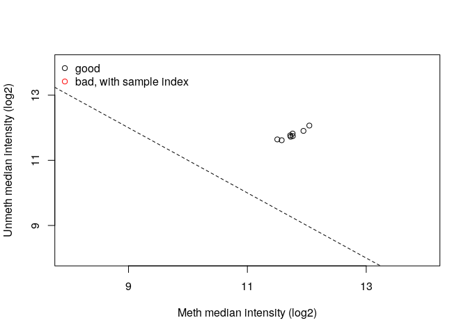

```r
MSet.raw %>%
        getQC() %>%
        plotQC()
```

All the samples are above the dashed line, meaning that the intensities are of good quality.

> Check the intensity of negative controls using minfi.

A very straightforward approach relies on the `controlStripPlot` function.

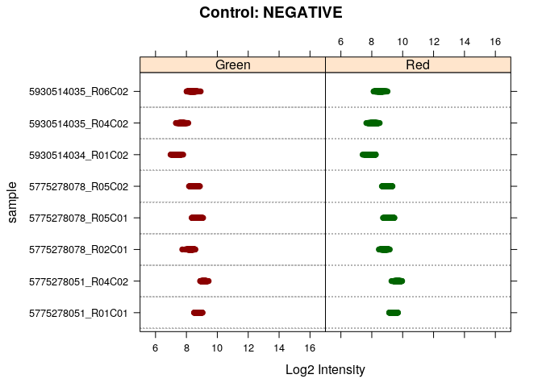

```r
controlStripPlot(RGset, controls = "NEGATIVE")
```

For some reason, the color of the probes is inverted. All the negatives are below background level (< 10 in log space), meaning that every slide passes the quality control. Moreover, the intensities are consistent between the two channels.

> Calculate detection pValues. For each sample, how many probes have a detection p-value higher than the threshold assigned to each student?

The function to use is `detectionP`, which takes as input the RGset. Some transformations of the dataset will be better explained in the next chunk. However, we do so to facilitate the subsequent step of filtering out the failed probes, which is not really necessary given their scarcity but is nice nonetheless.

```r
# Get the p-values
failed_probes <- RGset %>%
        detectionP() %>%
        as.data.frame()

# Get a summary for the details
probes_summary <- failed_probes > 0.01
summary(probes_summary)
```

```
##  5775278051_R01C01 5775278051_R04C02 5775278078_R02C01 5775278078_R05C01
##  Mode :logical     Mode :logical     Mode :logical     Mode :logical
##  FALSE:485189      FALSE:485252      FALSE:485200      FALSE:485027
##  TRUE :323         TRUE :260         TRUE :312         TRUE :485
##  5775278078_R05C02 5930514034_R01C02 5930514035_R04C02 5930514035_R06C02
##  Mode :logical     Mode :logical     Mode :logical     Mode :logical
##  FALSE:485047      FALSE:485389      FALSE:485452      FALSE:485363
##  TRUE :465         TRUE :123         TRUE :60          TRUE :149
```

```r
# Keep transforming
failed_probes %<>%
        rownames_to_column(var = "Name") %>%
        pivot_longer(-Name, names_to = "Slide", values_to = "PvalFailed") %>% # Convert to long format
        setDT() %>%
        filter(PvalFailed > 0.01)

pander(summary(failed_probes))
```

| Name | Slide | PvalFailed |
| --- | --- | --- |
| Length:2177 | Length:2177 | Min. :0.01001 |
| Class :character | Class :character | 1st Qu.:0.07849 |
| Mode :character | Mode :character | Median :0.35151 |
| NA | NA | Mean :0.44178 |
| NA | NA | 3rd Qu.:0.82454 |
| NA | NA | Max. :1.00000 |

The following table summarizes the failed positions

| Sample | Group | Slide | Row | Col | Failed probes (p-value > 0.01) |
| --- | --- | --- | --- | --- | --- |
| 1020 | DS | 5775278051 | 1 | 1 | 323 |
| 1036 | DS | 5775278051 | 4 | 2 | 260 |
| 3038 | WT | 5775278078 | 2 | 1 | 312 |
| 3042 | WT | 5775278078 | 5 | 1 | 485 |
| 3052 | WT | 5775278078 | 5 | 2 | 465 |
| 1016 | DS | 5930514034 | 1 | 2 | 123 |
| 1029 | DS | 5930514035 | 4 | 2 | 60 |
| 3029 | WT | 5930514035 | 6 | 2 | 149 |

# Raw intensities

> Calculate raw beta and M values and plot the densities of mean methylation values, dividing the samples in DS and WT.

The following chunk will create the object `methyl_data`, which will be our faithful companion for the rest of the report. This object will store as columns all the produced relevant data. For the retrieval of the $\beta$ and $M$ values we use the `getBeta` and `getM` functions respectively. We begin by creating the `beta` and `m` objects which will contain the beta values and m values from the `RGset`. Then, we proceed in merging the datatables to obtain `methyl_data`.

```r
# Extraction of beta
beta <- MSet.raw %>% # Get the object Mset.raw
        getBeta() %>% # Get the beta
        as.data.frame() %>% # Transform it into dataframe
        rownames_to_column(var = "Name") %>% # Create a new column called Name that stores the rownames
        pivot_longer(-Name, names_to = "Slide", values_to = "RawBeta") %>% # Transform from wide to long format
        setDT() # Convert to datatable

# Extraction of M
m <- MSet.raw %>% # Same for the m values
        getM() %>%
        as.data.frame() %>%
        rownames_to_column(var = "Name") %>%
        pivot_longer(-Name, names_to = "Slide", values_to = "RawM") %>%
        setDT()

# Join the datasets
methyl_data <- annotation %>%
        left_join(beta, by = "Name") %>%
        left_join(m, by = c("Name","Slide")) %>%
        anti_join(failed_probes, by = "Name") # Filter out failed probes

rm(m, beta, annotation) # Object are no longer necessary

# Lo and behold
pander(head(methyl_data))
```

| Name | chr | pos | Type | Slide | RawBeta | RawM |
| --- | --- | --- | --- | --- | --- | --- |
| cg00050873 | chrY | 9363356 | I | 5775278051_R01C01 | 0.8977 | 3.133 |
| cg00050873 | chrY | 9363356 | I | 5775278051_R04C02 | 0.8853 | 2.948 |
| cg00050873 | chrY | 9363356 | I | 5775278078_R02C01 | 0.91 | 3.338 |
| cg00050873 | chrY | 9363356 | I | 5775278078_R05C01 | 0.8594 | 2.612 |
| cg00050873 | chrY | 9363356 | I | 5775278078_R05C02 | 0.8904 | 3.022 |
| cg00050873 | chrY | 9363356 | I | 5930514034_R01C02 | 0.8923 | 3.05 |

The intermediate conversion to dataframe is necessary to avoid the loss of the probe names when converting again to `data.table`, since they are stored as `rownames` and not really supported in datatables. Before pivoting the dataframe, each column refers to a single slide of the experiment, and each row to a single probe. This was already seen when manipulating the `failed_probes`, and is called a wide format. After the transformation we can see that now each row is an independent observation, and that the new column `Slide` stores the name of the original `colname`. This type of format is usually referred to as long format. The latter is much more convenient to work with, and, most importantly, allows the addition of new columns rather easily. We also removed all the failed probes by name: this means that if a probe failed on a slide, it is removed also from all the other slides.

We now add a column for the Sample status, which can be either Down Syndrome (`DS`) or Wild Type (`WT`). The new operator `%<>%` work similarly to `%>%`, but also assigns the data to the object that is passed through the pipe. The `mutate` function performs data transformation on the object and adding a new column for the new values. We can also specify in which position to add the new `Group` column. The discrimination of `WT` and `DS` is implemented via the `if_else` function, which has two different returns based on the boolean evaluation provided as the first argument.

```r
# Adding the Group
slide_DS <- colnames(RGset[,targets$Group == "WT"])
methyl_data %<>%
        mutate(Group = if_else(Slide %in% slide_DS, "DS", "WT"), .before = RawBeta)
pander(head(methyl_data))
```

[output not shown]

## Plotting raw intesities

We can now generate the density plots for the `WT` and `DS` groups. The `group_by` function groups the observations (rows) by their value in the specified columns. Once again, the use of piping avoids the creation on unnecessary subsets (and lack of creativity for their naming). For the plot we will use the tools provided by `ggplot2`, which uses a very straightforward syntax.

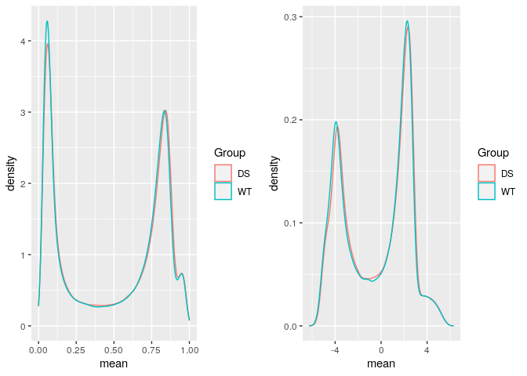

```r
# Plotting raw intensities
rawBetaplot <- methyl_data %>%
        group_by(Name, Group) %>%
        mutate(mean = mean(RawBeta, na.rm = T)) %>%
        ggplot(aes(x = mean)) +
        geom_density(aes(color = Group)) +
        xlim(0, 1)
rawMplot <-methyl_data %>%
        group_by(Name, Group) %>%
        mutate(mean = mean(RawM, na.rm = T)) %>%
        ggplot(aes(x = mean)) +
        geom_density(aes(color = Group))
grid.arrange(rawBetaplot, rawMplot, ncol = 2)
```

We can see how there is little to no difference between the two groups for both the $M$ and the $\beta$ values densities.

# Normalization

> Normalize the data using the function assigned to each student and compare raw data and normalized data.

My assigned function is the `preprocessSWAN`. The new `left_join` function handles the joining the two datasets by their common columns. The `.` indicates the destination of the pipe. When not present, it defaults to the first position of the called function, but in this case we need to join the results of the normalization to the `methylData`, and not the other way around.

```r
# Normalization with preprocessSWAN
methyl_data <- RGset %>%
        preprocessSWAN() %>%
        getBeta() %>%
        as.data.frame() %>%
        rownames_to_column(var = "Name") %>%
        pivot_longer(-Name, values_to = "NormBeta", names_to = "Slide") %>%
        anti_join(failed_probes, by = "Name") %>%
        left_join(methyl_data, ., by = c("Name", "Slide"))
```

> Produce a plot with 6 panels in which, for both raw and normalized data, you show the density plots of beta mean values according to the chemistry of the probes, the density plot of beta standard deviation values according to the chemistry of the probes and the boxplot of beta values.

We can now produce the plots and arrange them in a two by three fashion.

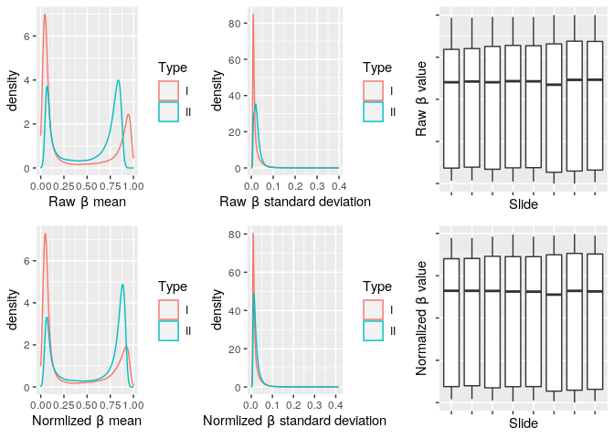

```r
# Density plot for raw beta mean
rawBetaMean <- methyl_data %>%
        group_by(Name, Type) %>%
        mutate(mean = mean(RawBeta, na.rm = T)) %>%
        ggplot(aes(x = mean)) +
        geom_density(aes(color = Type)) +
        xlim(0, 1) +
        xlab(expression("Raw"~ beta ~ "mean"))

# Density plot for raw beta standard deviation
rawBetaSD <- methyl_data %>%
        group_by(Name, Type) %>%
        mutate(sd = sd(RawBeta, na.rm = T)) %>%
        ggplot(aes(x = sd)) +
        geom_density(aes(color = Type)) +
        xlab(expression("Raw"~ beta ~ "standard deviation"))

# Boxplot for raw beta
rawBetaBox <- methyl_data %>%
        ggplot(aes(x = Slide, y = RawBeta)) +
        geom_boxplot() +
        theme(axis.text = element_blank()) +
        xlab("Slide") +
        ylab(expression("Raw" ~ beta ~ "value"))

# Density plot for Normlized beta mean
normBetaMean <- methyl_data %>%
        group_by(Name, Type) %>%
        mutate(mean = mean(NormBeta, na.rm = T)) %>%
        ggplot(aes(x = mean)) +
        geom_density(aes(color = Type)) +
        xlim(0, 1) +
        xlab(expression("Normlized"~ beta ~ "mean"))

# Density plot for Normlized beta standard deviation
normBetaSD <- methyl_data %>%
        group_by(Name, Type) %>%
        mutate(sd = sd(NormBeta, na.rm = T)) %>%
        ggplot(aes(x = sd)) +
        geom_density(aes(color = Type)) +
        xlab(expression("Normlized"~ beta ~ "standard deviation"))

# Boxplot for normalized beta values
normBetaBox <- methyl_data %>%
        ggplot(aes(x = Slide, y = NormBeta)) +
        geom_boxplot() +
        theme(axis.text = element_blank()) +
        xlab("Slide") +
        ylab(expression("Normalized"~ beta ~"value"))

# Arrange the plots in a 2x3 figure
grid.arrange(rawBetaMean, rawBetaSD, rawBetaBox, normBetaMean, normBetaSD, normBetaBox, nrow = 2)
```

> Provide a short comment regarding the changes you observe.

# Principal component analysis (PCA)

> Perform a PCA on the beta matrix generated in step 7. Comment the plot.

To perform the Principal Component Analysis we use the `procomp` function. After obtaning the PCA results we manipulate them a bit to make them more plot friendly.

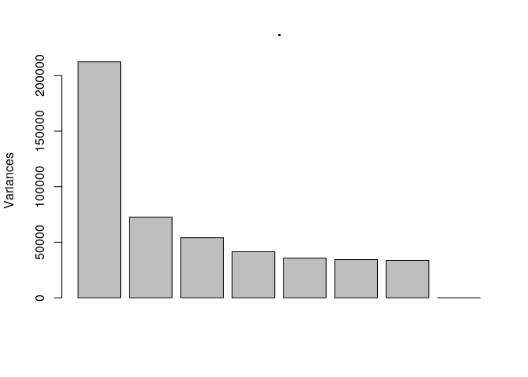

```r
pca_results <- methyl_data %>%
        select(Name, Slide, NormBeta) %>%
        pivot_wider(names_from = "Slide", values_from = "NormBeta") %>%
        column_to_rownames(var = "Name") %>%
        t() %>%
        prcomp(scale = TRUE) %T>%
        screeplot()
```

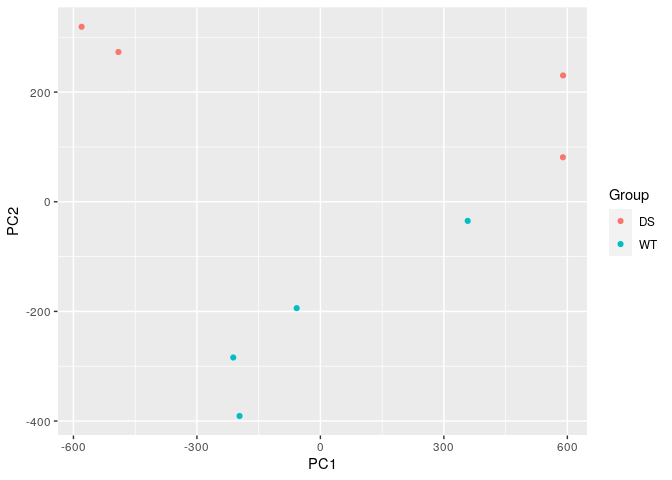

```r
pca_in <- data.table(pca_results$x) %>%
        add_column(Group = targets$Group)

ggplot(pca_in, aes(x = PC1, y = PC2, color = Group)) +
        geom_point()
```

From the scree plot we can see that all the variance is encapsulated by the first seven principal components. The eight component indeed doesn’t carry any variance, and the components from 2 to 7 have comparable levels of variance. The `PC1` vs `PC2` plot shows that the two groups can be separated with just the second principal component. Indeed, low values of `PC2` seem to correlate with Wild Type samples, and higher values of with Down Syndrome samples.

# Mann-Whitney U test

> Identify differentially methylated probes between group DS and group WT using the Mann-Whitney U Test.

We first define our custom `mann_whitney` function to be applied to all the rows in the dataset. In order to speed up the process, we use the `future.apply` package, which has multithreading enabled variants of the standard R `*apply` functions. Better yet, the `future` versions have exactly the same syntax as the default functions. *Note*: this allows to compute all the rows in under 4 minutes!

```r
groups <- factor(targets$Group)

# Custom function for the U test
mann_whitney <- function(x) {
  wilcox <- wilcox.test(x ~ groups)
  return(wilcox$p.value)
}

plan(multisession) # Enables multithreading

methyl_data %<>%
        select(Name, Slide, NormBeta) %>%
        pivot_wider(names_from = Slide, values_from = NormBeta) %>%
        column_to_rownames(var = "Name") %>%
        future_apply(1, mann_whitney) %>% # Future variant for multithreading
        data.frame() %>%
        rownames_to_column(var = "Name") %>%
        data.table() %>%
        setnames(".", "PvalRaw") %>%
        left_join(methyl_data, ., by = "Name")
```

# Multiple test correction

> Apply multiple test correction and set a significant threshold of 0.01.

We now have to account for multiple testing and adjust the *p*-values accordingly. Fortunately, the `p.adjust` function is already present.

```r
# Benjamini-Hockberg
methyl_data %<>%
        mutate(PvalBH = p.adjust(PvalRaw,"BH"))
# Bonferroni
methyl_data %<>%
        mutate(PvalBonf = p.adjust(PvalRaw,"bonferroni"))
```

> How many probes do you identify as differentially methylated considering nominal pValues? How many after Bonferroni correction? How many after BH correction?

We can do a preliminar check by using a boxplot.

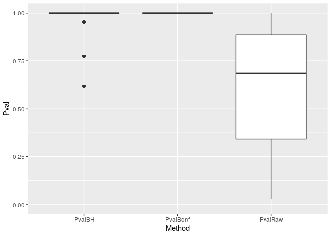

```r
methyl_data %>%
        select(PvalRaw, PvalBH, PvalBonf) %>%
        pivot_longer(everything(), names_to = "Method", values_to = "Pval") %>%
        ggplot(aes(x = Method, y = Pval)) +
        geom_boxplot() +
        ylim(0, 1)
```

The boxplot for the Raw p-values and the adjusted p-values clearly indicates that the correction was too aggressive. All the p-values adjusted with the Benjamini-Hockberg method are well above the significance threshold; even worse, the Bonferroni correction brought all the p-values to 1! To make sure there are no artifacts in the plot, we check again by querying the `methyl_data`.

```r
methyl_data[PvalRaw < 0.01 | PvalBH < 0.01 | PvalBonf < 0.01]
```

```
## Empty data.table (0 rows and 12 cols): Name,chr,pos,Type,Slide,Group...
```

Nothing to see here, we move along.

# Heatmaps

> Produce an heatmap of the top 100 differentially mehtylated probes.

After the correction, the only p-values that remain usable are the uncorrected ones. We will select the probes with the 100 lowest p-values (*i.e.* the most significant ones) and produce three different heatmaps using complete linkage, single linkage and average linkage for the calculation of the new distances.

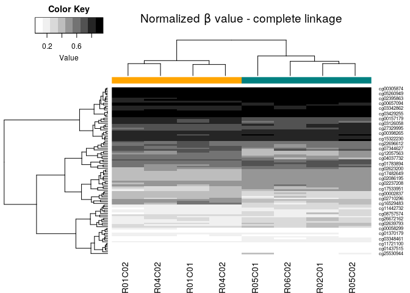

```r
# Preparation of the input dataset
heatmap_in <- methyl_data %>%
        select(Name, Slide, NormBeta, PvalRaw) %>%
        pivot_wider(names_from = Slide, values_from = NormBeta) %>%
        column_to_rownames(var = 'Name') %>%
        slice_min(PvalRaw, with_ties = F, n = 100) %>% # Selecting the 100 lowest p-values
        select(-PvalRaw) %>%
        as.matrix()

colorbar <- c("orange", "orange", "#008080", "#008080", "#008080", "orange", "orange", "#008080") # Some fancy color
palette <- brewer.pal(100, name = "Greys")

# Complete linkage
heatmap.2(heatmap_in,
          col = palette,
          Rowv = T,
          Colv = T,
          dendrogram = "both",
          key = T,
          ColSideColors = colorbar,
          density.info = "none",
          trace = "none",
          scale = "none",
          symm = F,
          main = expression("Normalized"~ beta ~"value - complete linkage"))
```

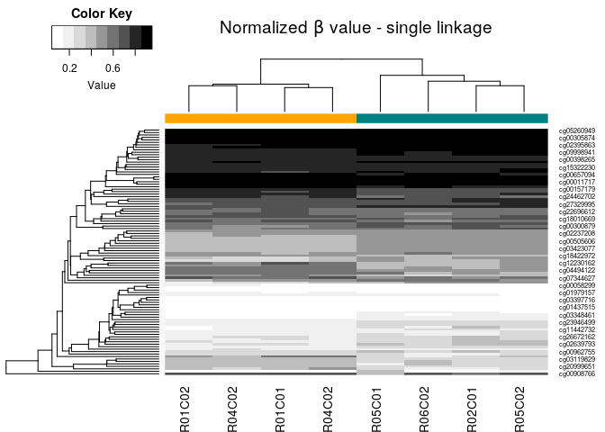

```r
# Single linkage
heatmap.2(heatmap_in,
          col = palette,
          Rowv = T,
          Colv = T,
          hclustfun = function(x) hclust(x, method = 'single'),
          dendrogram = "both",
          key = T,
          ColSideColors = colorbar,
          density.info = "none",
          trace = "none",
          scale = "none",
          symm = F,
          main = expression("Normalized"~ beta ~"value - single linkage"))
```

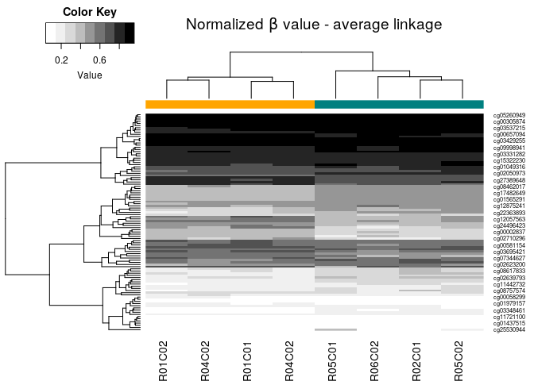

```r
# Averge linkage
heatmap.2(heatmap_in,
          col = palette,
          Rowv = T,
          Colv = T, hclustfun = function(x) hclust(x, method = 'average'),
          dendrogram = "both",
          key = T, ColSideColors = colorbar,
          density.info = "none",
          trace = "none",
          scale = "none",
          symm = F,
          main = expression("Normalized"~ beta ~"value - average linkage"))
```

The slides appear to be correctly clustered: the orange refers to the Down Syndrome samples, and the teal to the Wild-Type. The diffrent linkage methods produced different distances across the clusters. It is clearly visible the effect of *chaining* in the single linkage method.

# Volcano plot

> Produce a volcano plot of the results of differential methylation analysis.

To produce the volcano plot we will need two addtional values: the difference in average methylation(`delta`) for each probe among the two groups and the $-log_10$ of the *p*-value(`log_p`).

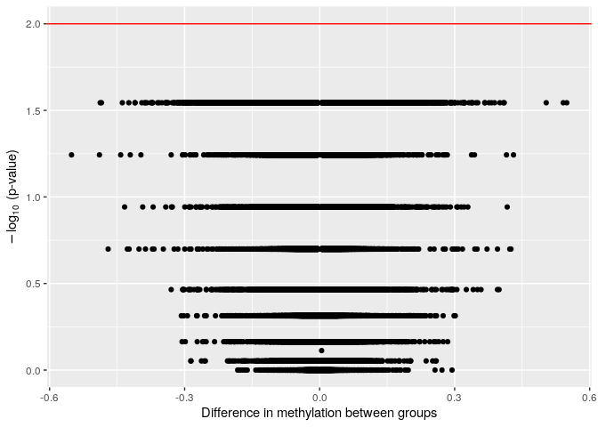

```r
# Difference in methylation accross Group
delta <- methyl_data %>%
                select(Name, NormBeta, Slide, Group) %>%
                group_by(Name, Group) %>%
                summarise(mean = mean(NormBeta, na.rm = T)) %>%
                group_by(Name) %>%
                summarise(Delta = diff(mean))

# Negative Log p value extraction
log_p <- methyl_data %>%
        select(Name, PvalRaw) %>%
        distinct() %>%
        mutate(PvalRaw = -log10(PvalRaw))

# Plot input
volplot_in <- merge(delta, log_p, by = "Name")

# Plotting
ggplot(data = volplot_in, aes(Delta, PvalRaw)) +
        geom_point() +
        geom_hline(yintercept = -log10(0.01), colour = "Red") +
        ylab(bquote(-log[10]~"(p-value)")) +
        xlab("Difference in methylation between groups")
```

Unfortunately, the Mann-Whytney U test made the volcano plot look more like a foggy morning than an actual volcano. Nevertheless, once again we clearly observe that no probe is above the significance threshold (the red line).

# Manhattan plot

> Produce a Manhattan plot of the results of differential methylation analysis.

For producing the manhattan plot we will use the `manhattan` function from the `qqman` package, which releases us from the hassle of reordering the chromosomes. Unfortunately, this function is designed to work with differently structured data, so we will need to transform it a little bit. In particular, we will use the `numericCHR` function from the `quantsmooth` package to convert the chromosomes values.

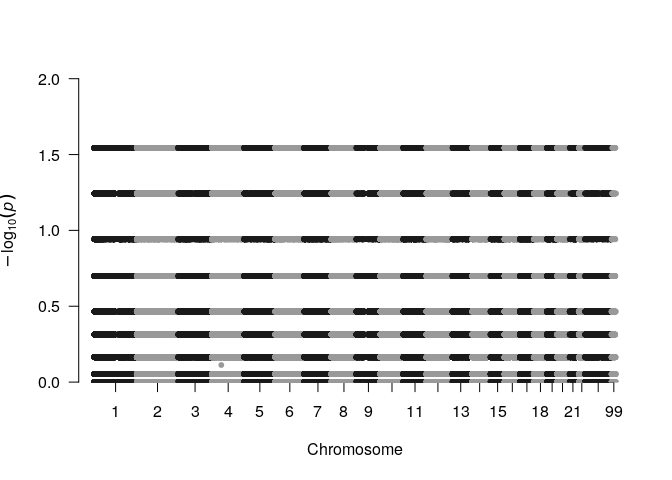

```r
# Data preparation
manhattan_in <- methyl_data %>%
        select(Name = Name, chr, pos, PvalRaw) %>%
        distinct() %>%
        as.data.table() %>%
        mutate(chr = numericCHR(chr))

# Plotting
manhattan(manhattan_in, chr = "chr", bp = "pos", snp = "Name", p = "PvalRaw")
```

The Manhattan plot also suffers from the U test. The sexual chromosome are reported as 98 (X) and 99 (Y). We can tell because of the much smaller amount of probes on the Y chromosome, which is indeed much smaller when compared to the X chromosome.

# Chromosome 21

> As DS is caused by the trisomy of chromosome 21, try also to plot the density of the methylation values of the probes mapping on chromosome 21.

First, we plot the density distribution for $\beta$ for the two groups.

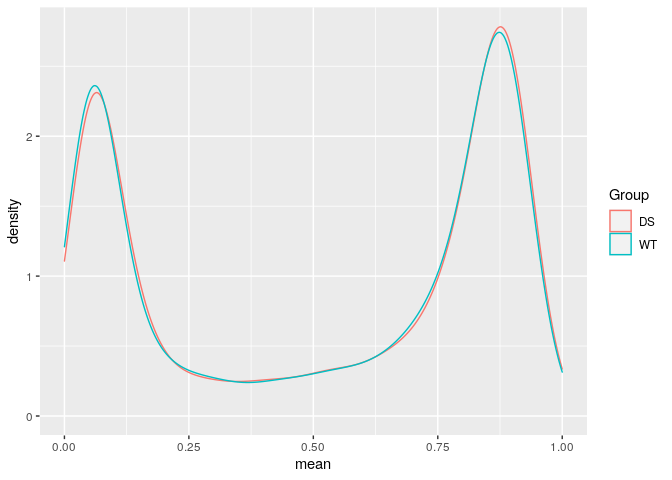

```r
methyl_data %>%
        filter(chr == "chr21") %>%
        group_by(Name, Group) %>%
        mutate(mean = mean(NormBeta, na.rm = T)) %>%
        ggplot(aes(x = mean)) +
        geom_density(aes(color = Group)) +
        xlim(0, 1)
```

> Do you see a very clear difference between the samples?

By looking at the distribution, it seems that there is no difference between the two groups.

> How many differentially methylated probes do you find on chromosome 21?

We already know that there are no significant probes, however, just for the sake of exercising we will double check.

```r
methyl_data[chr == "chr21" & PvalRaw < 0.01]
```

```
## Empty data.table (0 rows and 12 cols): Name,chr,pos,Type,Slide,Group...
```

As expected, the previous command return an empty result. No probes in chromosome 21 are above the 0.01 significance threshold.